# STAT/MATH 495: Problem Set 02

Sara Culhane, Meredith Manley, Brenna Sullivan

2017-09-19

# Exploratory Data Analysis

Looking at the distribution of housing prices, they were right skewed with a median of 6,274,411 Russian Rubles (determine they were Rubles based on currency conversions).

To choose a predictor we looked at several ggplots and determined that full_sq would be a resonable example though we did not do an exhaustive search. Since the value of real estate is generally determined by size, we thought that this would be a fair starting place to test out splines and not to worry to much about predictor selection.

We also removed all observations over 2000 square feet but ulimately this only improved our Kaggle score slightly. However, it greatly improved the correlation between the response and predictor.

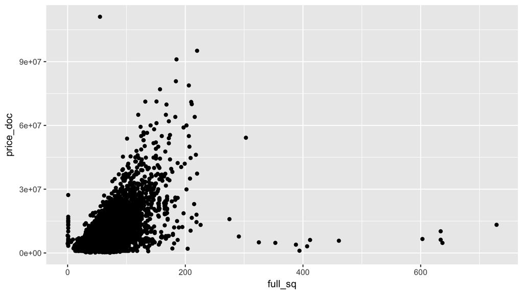

```r
train2 <- train[train$full_sq < 2000,] #observations of over 2000 removed from the data
ggplot(train2, aes(x=full_sq, y=price_doc)) + geom_point()
```

```r
cor(train2$full_sq,train2$price_doc)
```

```
## [1] 0.5628551
```

```r
cor(train$full_sq,train$price_doc)
```

```
## [1] 0.3418405
```

## Spline Visualization

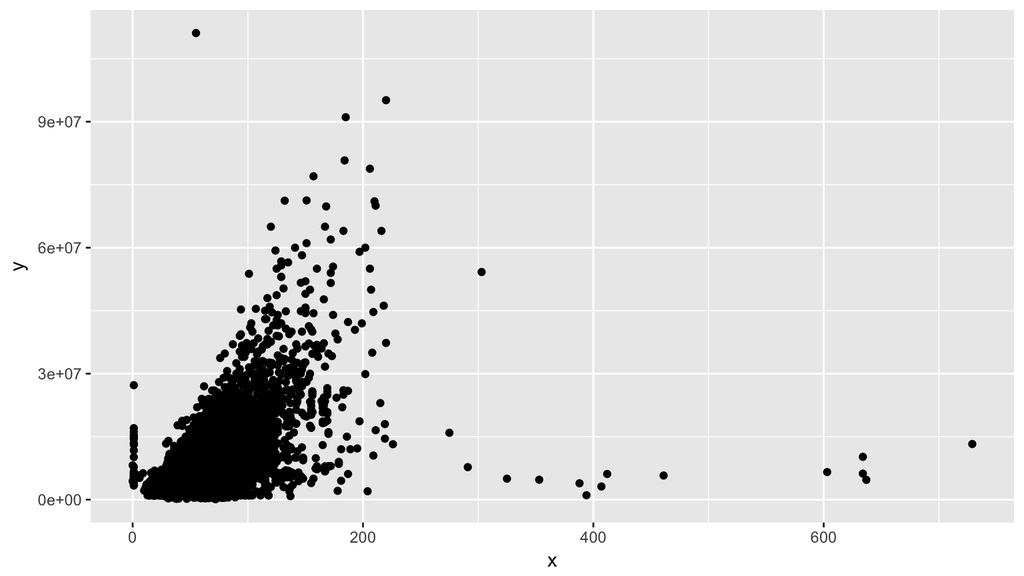

```r
values <- data_frame(
  x = train2$full_sq,
  y = train2$price_doc
)




values %>%
  ggplot(aes(x=x)) +
  geom_point(aes(y=y))
```

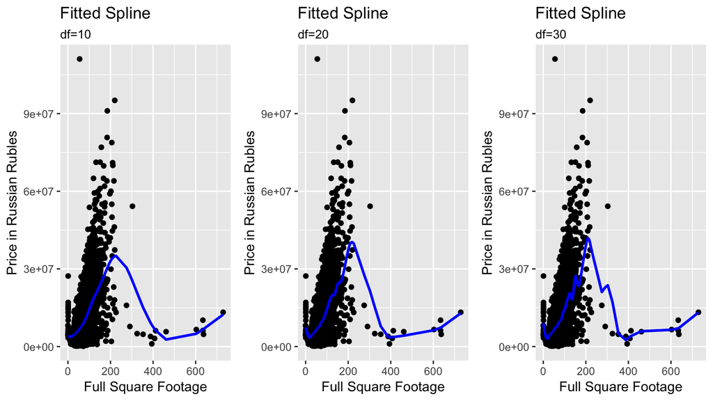

```r
p1 <- smooth.spline(values$x, values$y, df=10) %>%
  broom::augment() %>%
  ggplot(aes(x=x)) +
  geom_point(aes(y=y)) +
  geom_line(aes(y=.fitted), col="blue", size=1)+
  xlab("Full Square Footage")+
  ylab("Price in Russian Rubles")+
  ggtitle("Fitted Spline",subtitle= "df=10")
p2 <- smooth.spline(values$x, values$y, df=20) %>%
  broom::augment() %>%
  ggplot(aes(x=x)) +
  geom_point(aes(y=y)) +
  geom_line(aes(y=.fitted), col="blue", size=1)+
  xlab("Full Square Footage")+
  ylab("Price in Russian Rubles")+
  ggtitle("Fitted Spline",subtitle= "df=20")
p3 <- smooth.spline(values$x, values$y, df=30) %>%
  broom::augment() %>%
  ggplot(aes(x=x)) +
  geom_point(aes(y=y)) +
  geom_line(aes(y=.fitted), col="blue", size=1)+
  xlab("Full Square Footage")+
  ylab("Price in Russian Rubles")+
  ggtitle("Fitted Spline",subtitle= "df=30")
grid.arrange(p1, p2, p3,ncol=3)
```

# Model Fit

Examining the outputs of these models based on 10,20 and 30 df, we found that 20 had rougly the same adjusted $R^2$ as 30 but more significant knots (knots 24 through 27 wre not significant at at 0.05 alpha for df=30). We also know that higher degrees of freedom tend to overfit, thus since the difference in adjusted $R^2$ seemed negligible, $df=20$ seems to be the better choice.

```r
fit<-lm(y ~ bs(x,df=20),data = values )
summary(fit)
```

```
##
## Call:
## lm(formula = y ~ bs(x, df = 20), data = values)
##
## Residuals:
##       Min        1Q    Median        3Q       Max
## -26669030  -1783930    111027   1500811 103598624
##
## Coefficients:
##                   Estimate Std. Error t value Pr(>|t|)
## (Intercept)       10128049     813595  12.449  < 2e-16 ***
## bs(x, df = 20)1  -11325631    1660924  -6.819 9.35e-12 ***
## bs(x, df = 20)2   -6250957     894753  -6.986 2.88e-12 ***
## bs(x, df = 20)3   -5090408     845031  -6.024 1.72e-09 ***
## bs(x, df = 20)4   -4901707     826864  -5.928 3.10e-09 ***
## bs(x, df = 20)5   -4788888     826589  -5.794 6.96e-09 ***
## bs(x, df = 20)6   -5047067     835150  -6.043 1.53e-09 ***
## bs(x, df = 20)7   -4930292     843380  -5.846 5.09e-09 ***
## bs(x, df = 20)8   -4402689     832731  -5.287 1.25e-07 ***
## bs(x, df = 20)9   -4145029     841032  -4.929 8.33e-07 ***
## bs(x, df = 20)10  -4117283     852260  -4.831 1.36e-06 ***
## bs(x, df = 20)11  -3606814     833607  -4.327 1.52e-05 ***
## bs(x, df = 20)12  -2214097     839997  -2.636 0.008397 **
## bs(x, df = 20)13  -2860656     835108  -3.425 0.000614 ***
## bs(x, df = 20)14  -3068867     828810  -3.703 0.000214 ***
## bs(x, df = 20)15  -2330141     851596  -2.736 0.006219 **
## bs(x, df = 20)16    312071     831713   0.375 0.707503
## bs(x, df = 20)17  -1084367     818974  -1.324 0.185494
## bs(x, df = 20)18  62782546    1255737  49.997  < 2e-16 ***
## bs(x, df = 20)19 -54426520    4131363 -13.174  < 2e-16 ***
## bs(x, df = 20)20   9800257    2977502   3.291 0.000998 ***
## ---
## Signif. codes:  0 '***' 0.001 '**' 0.01 '*' 0.05 '.' 0.1 ' ' 1
##
## Residual standard error: 3707000 on 30449 degrees of freedom
## Multiple R-squared:  0.399,  Adjusted R-squared:  0.3987
## F-statistic:  1011 on 20 and 30449 DF,  p-value: < 2.2e-16
```

```r
fit2<-lm(y ~ bs(x,df=10),data = values )
fit3 <-lm(y ~ bs(x,df=30),data = values )
summary(fit2)
```

```
##
## Call:
## lm(formula = y ~ bs(x, df = 10), data = values)
##
## Residuals:
##       Min        1Q    Median        3Q       Max
## -25561309  -1829202    110723   1521738 103826863
##
## Coefficients:
##                   Estimate Std. Error t value Pr(>|t|)
## (Intercept)       10183660     797136  12.775  < 2e-16 ***
## bs(x, df = 10)1  -12563260    1424335  -8.820  < 2e-16 ***
## bs(x, df = 10)2   -5028813     785309  -6.404 1.54e-10 ***
## bs(x, df = 10)3   -5034338     810491  -6.211 5.32e-10 ***
## bs(x, df = 10)4   -4436227     800185  -5.544 2.98e-08 ***
## bs(x, df = 10)5   -4197083     811798  -5.170 2.35e-07 ***
## bs(x, df = 10)6   -2323262     802841  -2.894  0.00381 **
## bs(x, df = 10)7   -3459692     800585  -4.321 1.55e-05 ***
## bs(x, df = 10)8   55750332    1129201  49.371  < 2e-16 ***
## bs(x, df = 10)9  -30902774    3868473  -7.988 1.42e-15 ***
## bs(x, df = 10)10   1297287    2925693   0.443  0.65747
## ---
## Signif. codes:  0 '***' 0.001 '**' 0.01 '*' 0.05 '.' 0.1 ' ' 1
##
## Residual standard error: 3724000 on 30459 degrees of freedom
## Multiple R-squared:  0.3932, Adjusted R-squared:  0.393
## F-statistic:  1973 on 10 and 30459 DF,  p-value: < 2.2e-16
```

```r
summary(fit3)
```

```
##
## Call:
## lm(formula = y ~ bs(x, df = 30), data = values)
##
## Residuals:
##       Min        1Q    Median        3Q       Max
## -26992078  -1772937    109627   1509145 103533461
##
## Coefficients:
##                   Estimate Std. Error t value Pr(>|t|)
## (Intercept)        9797519     826212  11.858  < 2e-16 ***
## bs(x, df = 30)1   -8227210    1871311  -4.396 1.10e-05 ***
## bs(x, df = 30)2   -7991288     998379  -8.004 1.24e-15 ***
## bs(x, df = 30)3   -4654805     857800  -5.426 5.79e-08 ***
## bs(x, df = 30)4   -5299207     851762  -6.221 4.99e-10 ***
## bs(x, df = 30)5   -4373493     878716  -4.977 6.49e-07 ***
## bs(x, df = 30)6   -4159275     879526  -4.729 2.27e-06 ***
## bs(x, df = 30)7   -5872229    1023933  -5.735 9.84e-09 ***
## bs(x, df = 30)8   -3135703    1004664  -3.121 0.001803 **
## bs(x, df = 30)9   -5857447     974634  -6.010 1.88e-09 ***
## bs(x, df = 30)10  -4114468     880002  -4.676 2.94e-06 ***
## bs(x, df = 30)11  -4551045     867540  -5.246 1.57e-07 ***
## bs(x, df = 30)12  -3835144     859565  -4.462 8.16e-06 ***
## bs(x, df = 30)13  -3919244     846840  -4.628 3.71e-06 ***
## bs(x, df = 30)14  -3903389     881552  -4.428 9.55e-06 ***
## bs(x, df = 30)15  -3569399     894405  -3.991 6.60e-05 ***
## bs(x, df = 30)16  -3556161     856577  -4.152 3.31e-05 ***
## bs(x, df = 30)17  -2818389     858101  -3.284 0.001023 **
## bs(x, df = 30)18  -1956552     869154  -2.251 0.024386 *
## bs(x, df = 30)19  -2601102     865363  -3.006 0.002651 **
## bs(x, df = 30)20  -2151013     858542  -2.505 0.012236 *
## bs(x, df = 30)21  -2962055     855555  -3.462 0.000537 ***
## bs(x, df = 30)22  -2455419     849946  -2.889 0.003868 **
## bs(x, df = 30)23  -1830833     887686  -2.062 0.039171 *
## bs(x, df = 30)24    -97417     886277  -0.110 0.912476
## bs(x, df = 30)25     65399     849118   0.077 0.938609
## bs(x, df = 30)26   -284138     839352  -0.339 0.734973
## bs(x, df = 30)27    815877     838496   0.973 0.330549
## bs(x, df = 30)28  62683259    1420777  44.119  < 2e-16 ***
## bs(x, df = 30)29 -57734747    4303946 -13.414  < 2e-16 ***
## bs(x, df = 30)30  11770883    3024438   3.892 9.97e-05 ***
## ---
## Signif. codes:  0 '***' 0.001 '**' 0.01 '*' 0.05 '.' 0.1 ' ' 1
##
## Residual standard error: 3706000 on 30439 degrees of freedom
## Multiple R-squared:  0.3996, Adjusted R-squared:  0.399
## F-statistic: 675.3 on 30 and 30439 DF,  p-value: < 2.2e-16
```

```r
f <- makeFun(fit)
test$price_doc <- f(test$full_sq)
sub  <- test[,c(1,length(test))]
```

# Create Submission File

```r
write_csv(sub, "submission.csv")
```

Our Kaggle score with our model was 0.4099.